# Bacteria-plasmid interactions

### 2.1.7 Normalise by MAG abundance

- MAGs vary in their abundance, and this will affect the number of links
- We want the counts normalised in a way that assumes all MAGs were present at the same abundance
- To get this ‘theoretical’ same abundance, I use the mean abundance across MAGs
- If the mean abundance is 1%, but there is a MAG with 2% abundance, I normalise the count by multiplying it by (1/2 = 0.5).
- In this case, 0.5 is called the ‘scaling factor’ that I multiply counts by
- The scaling factor for each MAG is the mean MAG abundance divided by the specific MAG abundance
- However, I always add a psudocount of 1, to make sure when rounded, there are no zero counts (minimum count should always be 1)
- Same as just dividing by MAG abundance, but then you get <0 which is problematic for networks

```r
MAG_metadata <- read.csv(here("DATA","MAG_metadata.csv"))

MAG_metadata<-MAG_metadata[,1:8]
head(MAG_metadata)
```

|  | cluster_id | abundance | completeness | marker_gene_overrepresentation | marker_lineage | mash_reference | mash_hashes | mash_p.value |
| --- | --- | --- | --- | --- | --- | --- | --- | --- |
| 1 | bin_27 | 0.15079248 | 100.00 | 0.00 | k__Bacteria (UID2570) | Bacteroides_propionicifaciens_DSM_19291_JCM_14649.fna | 2 | 4.73e-08 |
| 2 | bin_29 | 0.12252569 | 100.00 | 1.19 | c__Deltaproteobacteria (UID3217) | Chlamydomonas_leiostraca.fna | 1 | 3.17e-06 |
| 3 | bin_45 | 0.03298376 | 97.53 | 0.19 | f__Lachnospiraceae (UID1256) | Lachnospiraceae_bacterium_1_1_57FAA.fna | 765 | 0.00e+00 |
| 4 | bin_42 | 0.14244040 | 97.51 | 0.62 | c__Gammaproteobacteria (UID4201) | Enhydrobacter_aerosaccus_SK60.fna | 8 | 1.16e-33 |
| 5 | bin_38 | 0.14468987 | 97.39 | 2.38 | c__Betaproteobacteria (UID3888) | Neisseria_shayeganii_871.fna | 7 | 2.21e-29 |
| 6 | bin_19 | 0.34848463 | 97.18 | 1.82 | c__Betaproteobacteria (UID3888) | Laribacter_hongkongensis_HLHK9.fna | 459 | 0.00e+00 |

```r
WW_links_filt9$Abundance<-vlookup(WW_links_filt9$MAG_assigment, MAG_metadata, lookup_column = "cluster_id", result_column = "abundance")

summary(WW_links_filt9$Abundance)
```

```
##     Min.  1st Qu.   Median     Mean  3rd Qu.     Max.
## 0.001783 0.039700 0.095816 0.229299 0.241427 1.630424
```

```r
# generate scaling factor to normalise by

WW_links_filt9$Scaling_factor<-  mean(WW_links_filt9$Abundance)/WW_links_filt9$Abundance

WW_links_filt9$Count_normalised<-WW_links_filt9$Count*WW_links_filt9$Scaling_factor
WW_links_filt9$Count_normalised<-WW_links_filt9$Count_normalised+1 # add psudocount of one so we can round it to the nearest integer (minimum 1)

summary(WW_links_filt9$Count_normalised)
```

```
##     Min.  1st Qu.   Median     Mean  3rd Qu.     Max.
##    1.281    5.574   14.532   43.583   37.024 5169.916
```

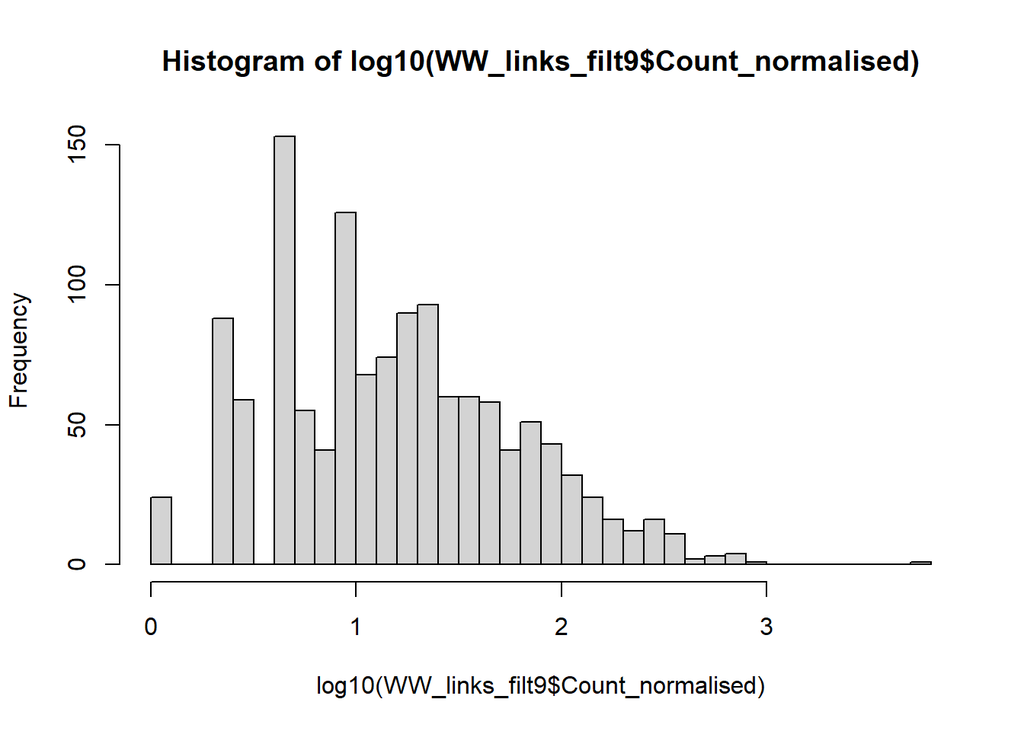

```r
WW_links_filt9$Count_normalised<-round(WW_links_filt9$Count_normalised,0)

hist(log10(WW_links_filt9$Count_normalised), breaks =50)
```

```r
head(WW_links_filt9)
```

| MAG_assigment | Cluster | Count | Resistance | Abundance | Scaling_factor | Count_normalised |
| --- | --- | --- | --- | --- | --- | --- |
| bin_1 | 4 | 2 | TRUE | 0.11840073 | 1.936632 | 5 |
| bin_1 | 81 | 2 | FALSE | 0.11840073 | 1.936632 | 5 |
| bin_10 | 4 | 2 | TRUE | 0.17045983 | 1.345177 | 4 |
| bin_10 | 144 | 240 | TRUE | 0.17045983 | 1.345177 | 324 |
| bin_10 | 297 | 2 | FALSE | 0.17045983 | 1.345177 | 4 |
| bin_103 | 7 | 11 | TRUE | 0.01896433 | 12.091045 | 134 |

### 2.1.8 Normalise by plasmid size

```r
WW_links_filt9$PlasmidLength<- vlookup(WW_links_filt9$Cluster, plasmid_length, lookup_column = 1, result_column = 2)


WW_links_filt9$Scaling_factor_length<-  mean(WW_links_filt9$PlasmidLength)/WW_links_filt9$PlasmidLength

WW_links_filt9$Count_normalised1<-WW_links_filt9$Count_normalised*WW_links_filt9$Scaling_factor_length
WW_links_filt9$Count_normalised1<-WW_links_filt9$Count_normalised1+1 # add psudocount of one so we can round it to the nearest integer (minimum 1)

summary(WW_links_filt9$Count_normalised1)
```

```
##     Min.  1st Qu.   Median     Mean  3rd Qu.     Max.
##    1.163   18.751   66.974  143.882  161.357 6104.971
```

```r
WW_links_filt9$Count_normalised1<-round(WW_links_filt9$Count_normalised1,0)
WW_links_filt9$Count_normalised<-WW_links_filt9$Count_normalised1
```

### 2.1.9 Convert count table into adjacency matrix

We have finished filtering, but at this point we need to generate a few bits of final information so that we can put it all together into a phyloseq object. Phyloseq is an R package that is used to handle 16S microbiome data, but it can also be used to handle other sorts of data like bacteria-plasmid associations.

We need: 1) A MAG x Plasmid count table/adjacency matrix 2) A dataframe with metadata for each MAG (eg Taxonomy) 3) a dataframe with metadata for each plasmid (ie Whether it has a resistance gene or not)

```r
# first we make the MAG x plasmic count table

WW_links_clustered2<-WW_links_filt9[,c("MAG_assigment", "Cluster", "Count_normalised")]

count_table_clustered<- pivot_wider( WW_links_clustered2, names_from = MAG_assigment, values_from = Count_normalised)

count_table_clustered[1:5, 1:5]
```

| Cluster | bin_1 | bin_10 | bin_103 | bin_104 |
| --- | --- | --- | --- | --- |
| 4 | 2 | 2 | NA | NA |
| 81 | 49 | NA | NA | NA |
| 144 | NA | 282 | NA | NA |
| 297 | NA | 5 | NA | NA |
| 7 | NA | NA | 23 | NA |

```r
##turn NAs to zeros
count_table_clustered_dt<-as.data.table(count_table_clustered)
count_table_clustered_dt[is.na(count_table_clustered_dt)] <- 0
count_table_clustered_dt[1:5, 1:5]
```

| Cluster | bin_1 | bin_10 | bin_103 | bin_104 |
| --- | --- | --- | --- | --- |
| 4 | 2 | 2 | 0 | 0 |
| 81 | 49 | 0 | 0 | 0 |
| 144 | 0 | 282 | 0 | 0 |
| 297 | 0 | 5 | 0 | 0 |
| 7 | 0 | 0 | 23 | 0 |

```r
count_table_clustered_df<-data.frame(count_table_clustered_dt)
#count_table_clustered_df[1:5,1:5]

#make first col row names
row.names(count_table_clustered_df)<-count_table_clustered_df$Cluster

# remove first column
count_table_clustered_df<-count_table_clustered_df[,-1]
count_table_clustered_df[1:5,1:5]
```

|  | bin_1 | bin_10 | bin_103 | bin_104 | bin_105 |
| --- | --- | --- | --- | --- | --- |
| 4 | 2 | 2 | 0 | 0 | 0 |
| 81 | 49 | 0 | 0 | 0 | 0 |
| 144 | 0 | 282 | 0 | 0 | 41 |
| 297 | 0 | 5 | 0 | 0 | 0 |
| 7 | 0 | 0 | 23 | 0 | 0 |

```r
# plasmid clusters are rows, MAGs are columns
```

### 2.1.10 Re-add MAGs that don’t associate with any plasmids

- MAGs which don’t associate with any plasmids were filtered out, therefore we need to add these back in

```r
# add column for bacterial species that are not associated with any plasmids
# these got removed as they had zero counts
mag_IDs<-unique(mag_assignment$cluster)
mags_to_add<-data.frame(mag_IDs)
mags_to_add$Included<-mags_to_add$mag_IDs %in% names(count_table_clustered_df)
mags_to_add<-subset(mags_to_add, Included==FALSE)
dim(mags_to_add)
```

```
## [1] 145   2
```

```r
df_to_add<-data.frame(matrix(0, nrow = nrow(count_table_clustered_df), ncol = nrow(mags_to_add)))
names(df_to_add)<-mags_to_add$mag_IDs
row.names(df_to_add)<-row.names(count_table_clustered_df)
new_count_table_clustered<-cbind(count_table_clustered_df, df_to_add)
dim(new_count_table_clustered)
```

```
## [1] 289 379
```

```r
#new_count_table_clustered[1:5,1:5]

print(getwd())
```

```
## [1] "C:/Users/risel/Dropbox/Sommer postdoc/Plasmid project/PlasmidProjectAnalysis/Updated analysis2/R SCRIPTS"
```

### 2.1.11 Generate MAG metadata

```r
#setwd("C:\\Users\\risel\\Dropbox\\Sommer postdoc\\Plasmid project\\PlasmidProjectAnalysis\\Updated analysis2")


## what do we know about MAG metadata
#MAG_metadata <- read.csv(here("DATA","MAG_metadata.csv"))
phylophlan_taxonomy <- read.csv(here("DATA","phylophlan_taxonomy_updated.csv"))

MAG_metadata<-MAG_metadata[,1:8]

new_mag_metadata<-merge(MAG_metadata, phylophlan_taxonomy, by.x = "cluster_id", by.y = "Bin")
dim(new_mag_metadata)
```

```
## [1] 379  15
```

```r
row.names(new_mag_metadata)<-new_mag_metadata$cluster_id
head(new_mag_metadata)
```

|  | cluster_id | abundance | completeness | marker_gene_overrepresentation | marker_lineage | mash_reference | mash_hashes | mash_p.value | Phylum | Class | Order | Family | Genus | Species | Distance |
| --- | --- | --- | --- | --- | --- | --- | --- | --- | --- | --- | --- | --- | --- | --- | --- |
| bin_1 | bin_1 | 0.11840073 | 92.05 | 2.91 | c__Gammaproteobacteria (UID4201) | Aeromonas_veronii_Hm21.fna | 4 | 3.33e-15 | p__Proteobacteria | c__Gammaproteobacteria | o__Gammaproteobacteria_unclassified | f__Candidatus_Competibacteraceae | g__Candidatus_Competibacter | s__Candidatus_Competibacter_denitrificans | 0.22246400 |
| bin_10 | bin_10 | 0.17045983 | 86.77 | 4.12 | o__Burkholderiales (UID4000) | Sphaerotilus_natans_subsp._natans_DSM_6575.fna | 211 | 0.00e+00 | p__Proteobacteria | c__Betaproteobacteria | o__Burkholderiales | f__Burkholderiales_unclassified | g__Sphaerotilus | s__Sphaerotilus_natans | 0.05100165 |
| bin_100 | bin_100 | 0.04211377 | 95.48 | 1.90 | p__Firmicutes (UID1022) | Peptoniphilus_obesi_ph1.fna | 3 | 1.21e-12 | p__Firmicutes | c__CFGB1874 | o__OFGB1874 | f__FGB1874 | g__GGB4971 | s__GGB4971_SGB6961 | 0.27824940 |
| bin_101 | bin_101 | 0.02808703 | 82.88 | 3.06 | o__Lactobacillales (UID543) | Lactococcus_raffinolactis_4877.fna | 47 | 6.12e-233 | p__Firmicutes | c__Bacilli | o__Lactobacillales | f__Streptococcaceae | g__Lactococcus | s__Lactococcus_raffinolactis | 0.01705703 |
| bin_102 | bin_102 | 0.01370204 | 37.93 | 8.62 | k__Bacteria (UID203) | Bacteroides_uniformis_dnLKV2.fna | 2 | 3.79e-08 | p__Firmicutes | c__Bacilli | o__Lactobacillales | f__Carnobacteriaceae | g__Jeotgalibaca | s__Jeotgalibaca_sp_PTS2502 | 0.28730900 |
| bin_103 | bin_103 | 0.01896433 | 31.03 | 0.00 | k__Bacteria (UID203) | Acinetobacter_bohemicus_ANC_3994.fna | 5 | 8.68e-21 | p__Proteobacteria | c__Gammaproteobacteria | o__Pseudomonadales | f__Moraxellaceae | g__Acinetobacter | s__Acinetobacter_guillouiae | 0.23308900 |

```r
#new_mag_metadata<-sample_data(new_mag_metadata)
#head(new_mag_metadata)
```

### 2.1.12 Generate plasmid metadata

```r
plasmid_metadata_clustered<-data.frame(unique(WW_links_filt9$Cluster))

#head(plasmid_metadata_clustered)
names(plasmid_metadata_clustered)<-"contigs_plasmids"

plasmid_metadata_clustered$Resistance<- plasmid_metadata_clustered$contigs_plasmids %in% resistance_clusters

head(plasmid_metadata_clustered)
```

|  | contigs_plasmids | Resistance |
| --- | --- | --- |
| 1 | 4 | TRUE |
| 2 | 81 | FALSE |
| 3 | 144 | TRUE |
| 4 | 297 | FALSE |
| 5 | 7 | TRUE |
| 6 | 13 | TRUE |

```r
table(plasmid_metadata_clustered$Resistance)
```

```
##
## FALSE  TRUE
##   257    32
```

```r
row.names(plasmid_metadata_clustered)<-plasmid_metadata_clustered$contigs_plasmids

# turn it into a tax_table object
plasmid_metadata_clustered<-tax_table(plasmid_metadata_clustered)
taxa_names(plasmid_metadata_clustered)<-data.frame(plasmid_metadata_clustered)$ta1

dim(plasmid_metadata_clustered)
```

```
## [1] 289   2
```

```r
head(plasmid_metadata_clustered)
```

```
## Taxonomy Table:     [6 taxa by 2 taxonomic ranks]:
##     ta1   ta2
## 4   "4"   "TRUE"
## 81  "81"  "FALSE"
## 144 "144" "TRUE"
## 297 "297" "FALSE"
## 7   "7"   "TRUE"
## 13  "13"  "TRUE"
```

### 2.1.13 Convert all layers into phyloseq object

```r
OTU = otu_table(new_count_table_clustered, taxa_are_rows = TRUE)
dim(new_count_table_clustered)
```

```
## [1] 289 379
```

```r
plasmid_ps_clustered<-merge_phyloseq(OTU, sample_data(new_mag_metadata), plasmid_metadata_clustered)

plasmid_ps_clustered
```

```
## phyloseq-class experiment-level object
## otu_table()   OTU Table:         [ 289 taxa and 379 samples ]
## sample_data() Sample Data:       [ 379 samples by 15 sample variables ]
## tax_table()   Taxonomy Table:    [ 289 taxa by 2 taxonomic ranks ]
```

```r
#saveRDS(plasmid_ps_clustered, "R_OUTPUT/plasmid_ps_clustered_04.03.22.RDS")
```

# 3 Analysis

```r
library(phyloseq)
library(ape)
library(phylosignal)
library(bipartite )
library(bipartiteD3)
library(reshape2)
library(expss)
library(ggsci)
library(tidyverse)
library(metagMisc)
library(igraph)
library(network)
library(intergraph)
library(scales)
library(qgraph)
library(ggpubr)
library(gridExtra)
library(jntools)
library(ggtree)
library(ggplotify)
library(gtable)
library(grid)
library(RColorBrewer)
library(forcats)
library(ggridges)
#library(bmotif)
#library(ggcorrplot)
library(viridis)
library(here)
library(ggrepel)
library(ggstatsplot)
library(ggthemes)
library(ggnetwork)
```

```r
#plasmid_ps_clustered<-readRDS( "R_OUTPUT/plasmid_ps_clustered_04.03.22.RDS")
#resistance_clusters<- readRDS( "resistance_clusters.RDS")
#cluster_df<-readRDS("cluster_membership.RDS")


phylo_merged<-plasmid_ps_clustered

tr<-read.tree(here("DATA","phylophlan.tre.treefile")) #phylo tree for genome clusters
tree_rooted<-root(tr, outgroup = "bin_174") # root tree with chloroflexi MAG

taxonomy<-read.csv("C:/Users/risel/Dropbox/Sommer postdoc/Plasmid project/PlasmidProjectAnalysis/Updated analysis2/DATA/phylophlan_taxonomy_updated.csv")
```

```r
### lightly filter - a few MAGs don't appear in the phylogenetic tree

phylo_filtered<-prune_samples(tr$tip.label, phylo_merged)
phylo_filtered<-prune_taxa(taxa_sums(phylo_filtered) > 1, phylo_filtered)

phylo_filtered
```

```
## phyloseq-class experiment-level object
## otu_table()   OTU Table:         [ 289 taxa and 374 samples ]
## sample_data() Sample Data:       [ 374 samples by 15 sample variables ]
## tax_table()   Taxonomy Table:    [ 289 taxa by 2 taxonomic ranks ]
```

```r
sum(taxa_sums(phylo_filtered))
```

```
## [1] 183413
```

```r
summary(taxa_sums(phylo_filtered))
```

```
##    Min. 1st Qu.  Median    Mean 3rd Qu.    Max.
##     4.0   123.0   307.0   634.6   709.0  6992.0
```

### 3.0.1 Plasmid statistics

```r
plasmid_prev_df<-data.frame(microbiome::prevalence(phylo_filtered, count = T))
names(plasmid_prev_df)<-"Prev"
plasmid_prev_df$Abundance<-taxa_sums(phylo_filtered)
plasmid_prev_df$Rel_Abundance<-plasmid_prev_df$Abundance/(sum(plasmid_prev_df$Abundance))
plasmid_prev_df<-plasmid_prev_df %>% arrange(-Prev)
head(plasmid_prev_df)
```

|  | Prev | Abundance | Rel_Abundance |
| --- | --- | --- | --- |
| 4 | 80 | 1337 | 0.007289560 |
| 24 | 45 | 4897 | 0.026699307 |
| 144 | 39 | 1205 | 0.006569872 |
| 52 | 35 | 6761 | 0.036862164 |
| 2 | 34 | 2839 | 0.015478728 |
| 7 | 32 | 317 | 0.001728340 |

```r
plasmid_prev_df$Cluster<-row.names(plasmid_prev_df)
plasmid_prev_df$Resistance <- plasmid_prev_df$Cluster %in% resistance_clusters

## add plasmid length and number of contigs

plasmid_length$ContigNo<- vlookup(plasmid_length$ClusterMembership, contig_no, lookup_column = 1, result_column = 2)
head(plasmid_length)
```

| ClusterMembership | TotalLengthKB | ContigNo |
| --- | --- | --- |
| 1 | 3507 | 6 |
| 2 | 6108 | 5 |
| 3 | 58176 | 5 |
| 4 | 78669 | 10 |
| 5 | 2567 | 6 |
| 6 | 4236 | 4 |

```r
plasmid_prev_df<-merge(plasmid_prev_df, plasmid_length, by.x = "Cluster", by.y = "ClusterMembership")
dim(plasmid_prev_df)
```

```
## [1] 289   7
```

```r
#plasmid_prev_df<-plasmid_prev_df %>% arrange(-ContigNo)
plasmid_prev_df<-plasmid_prev_df %>% arrange(-Prev)


summary(plasmid_prev_df$Prev)
```

```
##    Min. 1st Qu.  Median    Mean 3rd Qu.    Max.
##   1.000   1.000   2.000   4.509   5.000  80.000
```

```r
plasmid_prevalence<-ggplot(plasmid_prev_df, aes(x= Prev))+
  geom_histogram(col = "white", boundary = 0)+
  theme_clean(base_size = 16)+
  scale_x_sqrt(breaks = c(1,2,3,5,10,20,30,50,75,100))+
 # ggtitle("Number of MAG associations per plasmid")+
  ylab("Frequency")+
  xlab("Number of MAG associations per plasmid")
```

## 3.1 Top 10 plasmids

```r
head(plasmid_prev_df)
```

|  | Cluster | Prev | Abundance | Rel_Abundance | Resistance | TotalLengthKB | ContigNo |
| --- | --- | --- | --- | --- | --- | --- | --- |
| 1 | 4 | 80 | 1337 | 0.007289560 | TRUE | 78669 | 10 |
| 2 | 24 | 45 | 4897 | 0.026699307 | TRUE | 6757 | 2 |
| 3 | 144 | 39 | 1205 | 0.006569872 | TRUE | 13835 | 2 |
| 4 | 52 | 35 | 6761 | 0.036862164 | TRUE | 7357 | 3 |
| 5 | 2 | 34 | 2839 | 0.015478728 | TRUE | 6108 | 5 |
| 6 | 7 | 32 | 317 | 0.001728340 | TRUE | 73524 | 9 |

```r
top10plasmids<-plasmid_prev_df[1:10,]$Cluster

head(cluster_df)
```

|  | name | ClusterMembership | Resistance | ContigNo | LengthKB |
| --- | --- | --- | --- | --- | --- |
| 122 | k141_3140497 | 1 | FALSE | 6 | 414 |
| 159 | k141_1718662 | 1 | TRUE | 6 | 519 |
| 1251 | k141_1847458 | 1 | FALSE | 6 | 882 |
| 4881 | k141_2333875 | 1 | FALSE | 6 | 892 |
| 6191 | k141_2279036 | 1 | TRUE | 6 | 301 |
| 7361 | k141_261801 | 1 | FALSE | 6 | 499 |

```r
cluster_df$Top10 <-cluster_df$ClusterMembership %in% top10plasmids

top10<-subset(cluster_df, Top10==T)
head(top10)
```

|  | name | ClusterMembership | Resistance | ContigNo | LengthKB | Top10 |
| --- | --- | --- | --- | --- | --- | --- |
| 735 | k141_2110272 | 2 | FALSE | 5 | 1632 | TRUE |
| 747 | k141_2112326 | 2 | TRUE | 5 | 1596 | TRUE |
| 761 | k141_1547410 | 2 | FALSE | 5 | 261 | TRUE |
| 4161 | k141_154670 | 2 | FALSE | 5 | 1254 | TRUE |
| 442 | k141_1854654 | 2 | TRUE | 5 | 1365 | TRUE |
| 537 | k141_2957667 | 4 | FALSE | 10 | 7450 | TRUE |

```r
length(unique(top10$ClusterMembership))
```

```
## [1] 10
```

```r
top10<-merge(top10, plasmid_prev_df, by.x = "ClusterMembership", by.y = "Cluster")
dim(top10)
```

```
## [1] 49 12
```

```r
length(unique(top10$ClusterMembership))
```

```
## [1] 10
```

```r
#head(top10)

top10<-top10[,c("name", "ClusterMembership", "Prev", "TotalLengthKB", "Resistance.x")]
#head(top10)
names(top10)<-c("Contig", "Cluster", "Prevalence", "ClusterLength", "Resistance")
#write.table(top10, "Top10plasmids.csv", sep = ",")

top10
```

| Contig | Cluster | Prevalence | ClusterLength | Resistance |
| --- | --- | --- | --- | --- |
| k141_654371 | 13 | 28 | 16343 | TRUE |
| k141_778564 | 13 | 28 | 16343 | FALSE |
| k141_2984227 | 13 | 28 | 16343 | TRUE |
| k141_143124 | 13 | 28 | 16343 | FALSE |
| k141_693513 | 13 | 28 | 16343 | TRUE |
| k141_266523 | 13 | 28 | 16343 | FALSE |
| k141_1982304 | 13 | 28 | 16343 | FALSE |
| k141_195801 | 13 | 28 | 16343 | FALSE |
| k141_483417 | 13 | 28 | 16343 | FALSE |
| k141_940341 | 13 | 28 | 16343 | FALSE |

[output cut: 39 more lines]

## 3.2 MAG statistics

```r
bacteria_alpha<-phyloseq::estimate_richness(phylo_filtered, measures = c("Observed"))
head(bacteria_alpha)
```

|  | Observed |
| --- | --- |
| bin_1 | 2 |
| bin_10 | 3 |
| bin_103 | 6 |
| bin_104 | 10 |
| bin_105 | 2 |
| bin_106 | 1 |

```r
bacteria_alpha$id<-row.names(bacteria_alpha)

summary(bacteria_alpha$Observed)
```

```
##    Min. 1st Qu.  Median    Mean 3rd Qu.    Max.
##   0.000   0.000   1.000   3.484   4.000  47.000
```

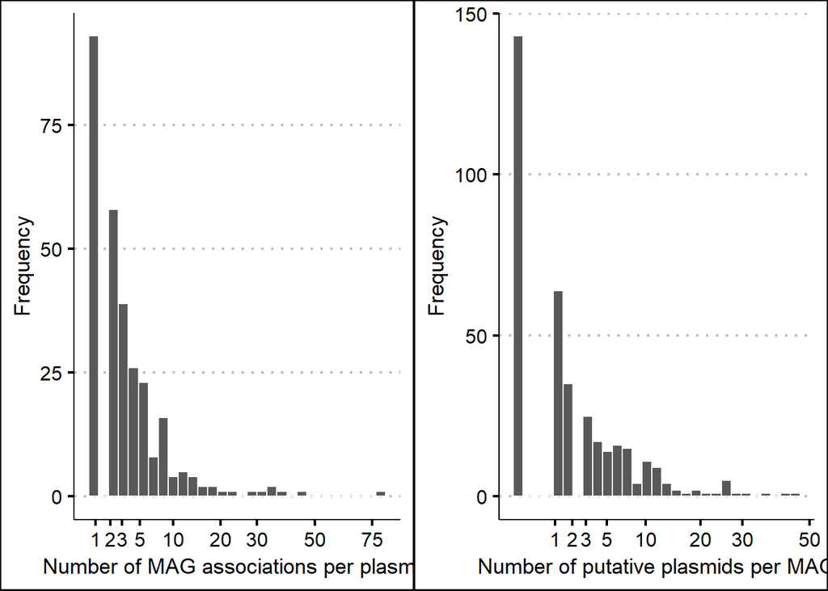

```r
MAG_prevalence<-ggplot(bacteria_alpha, aes(x= Observed))+
  geom_histogram(col = "white", boundary = 0)+
  theme_clean(base_size = 16)+
  scale_x_sqrt(breaks = c(0,1,2,3,5,10,20,30,50,75,100))+
 # ggtitle("Number of plasmid associations per MAG")+
  ylab("Frequency")+
  xlab("Number of putative plasmids per MAG")


ggarrange(plasmid_prevalence, MAG_prevalence)
```

```r
#head(plasmid_prev_df)
#head(bacteria_alpha)

plasmid_prev<-plasmid_prev_df[,c(1,2)]
names(plasmid_prev)<-c("id", "Number")
#head(plasmid_prev)
names(bacteria_alpha)[1]<-"Number"

bacteria_alpha$Identity<-"MAG"
plasmid_prev$Identity<-"Plasmid"

head(bacteria_alpha)
```

|  | Number | id | Identity |
| --- | --- | --- | --- |
| bin_1 | 2 | bin_1 | MAG |
| bin_10 | 3 | bin_10 | MAG |
| bin_103 | 6 | bin_103 | MAG |
| bin_104 | 10 | bin_104 | MAG |
| bin_105 | 2 | bin_105 | MAG |
| bin_106 | 1 | bin_106 | MAG |

```r
head(plasmid_prev)
```

|  | id | Number | Identity |
| --- | --- | --- | --- |
| 1 | 4 | 80 | Plasmid |
| 2 | 24 | 45 | Plasmid |
| 3 | 144 | 39 | Plasmid |
| 4 | 52 | 35 | Plasmid |
| 5 | 2 | 34 | Plasmid |
| 6 | 7 | 32 | Plasmid |

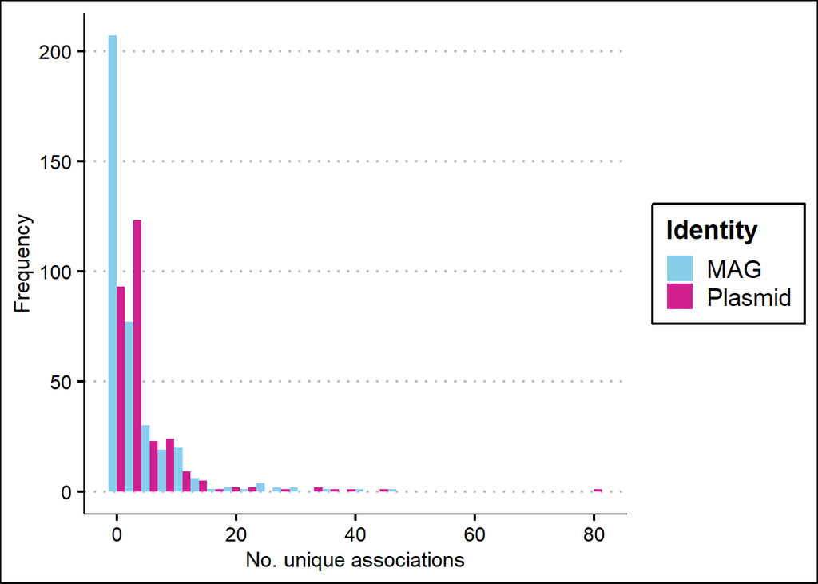

```r
distributions_df<-rbind(plasmid_prev, bacteria_alpha)

ggplot(distributions_df, aes(x = Number, group = Identity, fill = Identity))+
  geom_histogram( position="dodge")+
  theme_clean(base_size = 16)+
  scale_fill_manual(values = c("skyblue", "violetred"))+
  ylab("Frequency")+
  xlab("No. unique associations")
```

### 3.2.1 Plot bacterial phylogenetic tree

*Edit tree so ordered by taxonomy

```r
## edit tree

head(taxonomy)
```

|  | Bin | Phylum | Class | Order | Family | Genus | Species | Distance |
| --- | --- | --- | --- | --- | --- | --- | --- | --- |
| 1 | bin_361 | p__Firmicutes | c__Tissierellia | o__Tissierellales | f__Tissierellaceae | g__Tissierella | s__Tissierella_creatinophila | 0.3395860 |
| 2 | bin_15 | p__Proteobacteria | c__Betaproteobacteria | o__Burkholderiales | f__Comamonadaceae | g__Acidovorax | s__Acidovorax_sp_GW101_3H11 | 0.1917310 |
| 3 | bin_180 | p__Bacteroidetes | c__CFGB2107 | o__OFGB2107 | f__FGB2107 | g__GGB6000 | s__GGB6000_SGB8623 | 0.2873090 |
| 4 | bin_177 | p__Actinobacteria | c__Actinobacteria | o__Propionibacteriales | f__Propionibacteriaceae | g__Propionibacterium | s__Propionibacterium_acidifaciens | 0.2661355 |
| 5 | bin_277 | p__Bacteroidetes | c__Bacteroidia | o__Bacteroidales | f__Prevotellaceae | g__GGB1234 | s__GGB1234_SGB1613 | 0.1031755 |
| 6 | bin_129 | p__Firmicutes | c__Clostridia | o__Clostridiales | f__Clostridiaceae | g__Alkaliphilus | s__Alkaliphilus_metalliredigens | 0.3532800 |

```r
str(taxonomy)
```

```
## 'data.frame':    379 obs. of  8 variables:
##  $ Bin     : chr  "bin_361" "bin_15" "bin_180" "bin_177" ...
##  $ Phylum  : chr  "p__Firmicutes" "p__Proteobacteria" "p__Bacteroidetes" "p__Actinobacteria" ...
##  $ Class   : chr  "c__Tissierellia" "c__Betaproteobacteria" "c__CFGB2107" "c__Actinobacteria" ...
##  $ Order   : chr  "o__Tissierellales" "o__Burkholderiales" "o__OFGB2107" "o__Propionibacteriales" ...
##  $ Family  : chr  "f__Tissierellaceae" "f__Comamonadaceae" "f__FGB2107" "f__Propionibacteriaceae" ...
##  $ Genus   : chr  "g__Tissierella" "g__Acidovorax" "g__GGB6000" "g__Propionibacterium" ...
##  $ Species : chr  "s__Tissierella_creatinophila" "s__Acidovorax_sp_GW101_3H11" "s__GGB6000_SGB8623" "s__Propionibacterium_acidifaciens" ...
##  $ Distance: num  0.34 0.192 0.287 0.266 0.103 ...
```

```r
taxonomy$Phylum<-factor(taxonomy$Phylum)
taxonomy$Class<-factor(taxonomy$Class)
taxonomy$Order<-factor(taxonomy$Order)
taxonomy$Family<-factor(taxonomy$Family)
taxonomy$Genus<-factor(taxonomy$Genus)
taxonomy$Bin<-factor(taxonomy$Bin)

frm <- ~Phylum/Class/Order/Family/Genus/Bin
tree <- as.phylo(frm, data = taxonomy, collapse=FALSE)
tree$edge.length <- rep(1, nrow(tree$edge))
#plot(tree)
tree_rooted<-tree

droptips<-tree_rooted$tip.label[!tree_rooted$tip.label %in% sample_names(phylo_filtered)]

tree_rooted<-drop.tip(tree_rooted, tip = droptips)
```

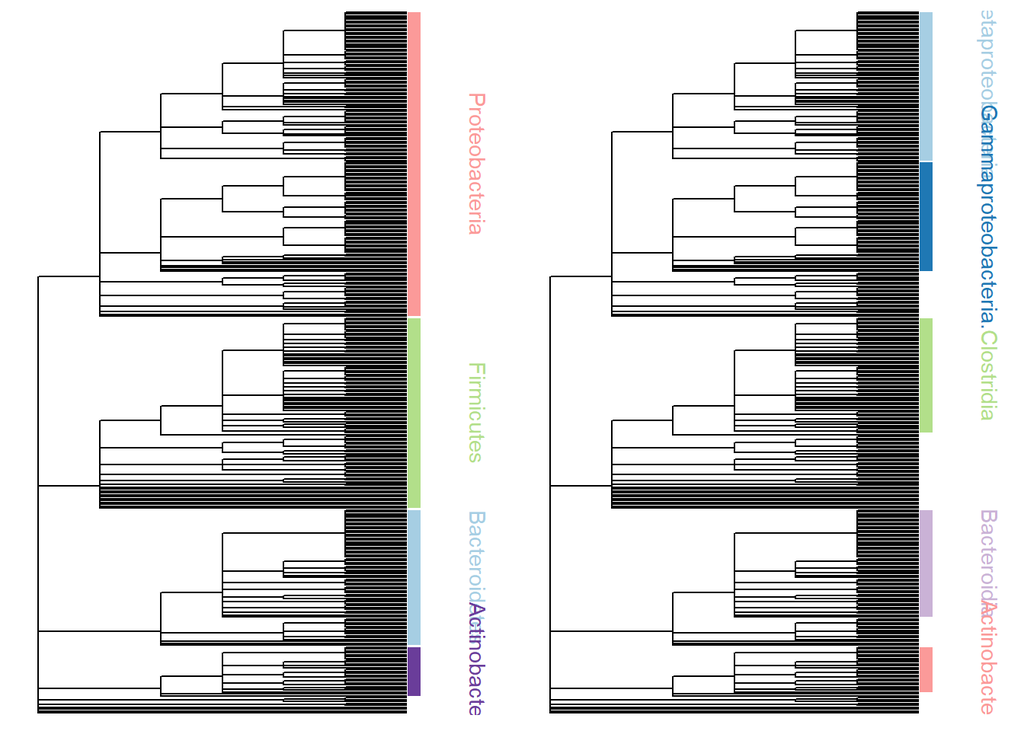

```r
# make large colour vector
mypal1<-brewer.pal(12,"Paired")
mypal2<-brewer.pal(12,"Dark2")
mypal3<-c(mypal1, mypal2)
#scales::show_col(mypal3)


### find nodes
## phylum level


### find nodes
tree_rooted$Phylum<-vlookup(tree_rooted$tip.label, taxonomy, lookup_column = "Bin", result_column = "Phylum")
tree_rooted$Phylum<-as.character(tree_rooted$Phylum)
tree_rooted$Phylum<-ifelse(is.na(tree_rooted$Phylum), "Unknown", tree_rooted$Phylum)
tr2<-tree_rooted
tr2$tip.label<-tree_rooted$Phylum

#ggtree(tr2, branch.length = "none",aes(color=branch.length)) +
# xlim(0, 26) +
#geom_tiplab(size=1, color="plum1", offset = 0.5) +
# geom_label2(aes(subset=!isTip, label=node), size=2, color="darkred", alpha=0.8) +
# theme_tree2("black") +
# scale_color_continuous(low='white', high='hotpink', name="Branch length (my)") +
#  theme(legend.position="bottom")


tree_phylum<-ggtree(tree_rooted, branch.length = "none")+
  geom_cladelabel(node=414,  col=mypal3[5], label ="Proteobacteria", barsize=3, align=T, angle=270, offset.text=1, hjust='center') + #betaproteobacteri
  geom_cladelabel(node=376, col=mypal3[3],  label ="Firmicutes", barsize=3, align=T, angle=270, offset.text=1, hjust='center') + #gamma pr
  geom_cladelabel(node=463, col=mypal3[1],  label ="Bacteroidetes", barsize=3, align=T, angle=270, offset.text=1, hjust='center') + #Bacteroidaceae
  geom_cladelabel(node=481, col=mypal3[10],  label ="Actinobacteria", barsize=3, align=T, angle=270, offset.text=1, hjust='center')

################ class level ###########
################ class level ###########
################ class level ###########
################ class level ###########

tree_rooted$Class<-vlookup(tree_rooted$tip.label, taxonomy, lookup_column = "Bin", result_column = "Class")
tree_rooted$Class<-as.character(tree_rooted$Class)
tree_rooted$Class<-ifelse(is.na(tree_rooted$Class), "Unknown", tree_rooted$Class)
tr2<-tree_rooted
tr2$tip.label<-tree_rooted$Class

#ggtree(tr2, branch.length = "none",aes(color=branch.length)) +
# xlim(0, 26) +
#geom_tiplab(size=1, color="plum1", offset = 0.5) +
# geom_label2(aes(subset=!isTip, label=node), size=2, color="darkred", alpha=0.8) +
# theme_tree2("black") +
# scale_color_continuous(low='white', high='hotpink', name="Branch length (my)") +
#  theme(legend.position="bottom")


tree_class<-ggtree(tree_rooted, branch.length = "none")+
  geom_cladelabel(node=415,  col=mypal3[1], label ="Betaproteobacteria", barsize=3, align=T, angle=270, offset.text=1, hjust='center') + #betaproteobacteri
  geom_cladelabel(node=440, col=mypal3[2],  label ="Gammaproteobacteria.", barsize=3, align=T, angle=270, offset.text=1, hjust='center') + #gamma pr
  geom_cladelabel(node=464, col=mypal3[9],  label ="Bacteroidia", barsize=3, align=T, angle=270, offset.text=1, hjust='center') + #Bacteroidaceae
  geom_cladelabel(node=379, col=mypal3[3],  label ="Clostridia", barsize=3, align=T, angle=270, offset.text=1, hjust='center') + # clostridia
  geom_cladelabel(node=482, col=mypal3[5],  label ="Actinobacteria", barsize=3, align=T, angle=270, offset.text=1, hjust='center')  #actinobacteria

ggarrange(tree_phylum, tree_class)
```

### 3.2.2 Generate network statistics

```r
net.v<-data.frame(phylo_filtered@otu_table@.Data)
  # this will estimate all common network metrics but may take a while
  network_metrics<-data.frame(networklevel(net.v, index = c( "NODF", "number of compartments")))
names(network_metrics)[1]<-"Stat"

ps_noAMR<-subset_taxa(phylo_filtered, ta2 == FALSE)
ps_noAMR<-prune_samples(sample_sums(ps_noAMR)>0, ps_noAMR)
net.noAMR<-data.frame(ps_noAMR@otu_table@.Data)
network_metrics_noAMR<-data.frame(networklevel(net.noAMR, index = c("NODF", "number of compartments")))
 names(network_metrics_noAMR)[1]<-"Stat"

## just AMR


ps_AMR<-subset_taxa(phylo_filtered, ta2 == TRUE)
ps_AMR<-prune_samples(sample_sums(ps_AMR)>0, ps_AMR)
net.AMR<-data.frame(ps_AMR@otu_table@.Data)
network_metrics_AMR<-data.frame(networklevel(net.AMR, index = c( "NODF", "number of compartments")))
names(network_metrics_AMR)[1]<-"Stat"


network_metrics
```

|  | Stat |
| --- | --- |
| number of compartments | 3.000000 |
| NODF | 9.524304 |

```r
network_metrics_noAMR
```

|  | Stat |
| --- | --- |
| number of compartments | 10.000000 |
| NODF | 5.374072 |

```r
network_metrics_AMR
```

|  | Stat |
| --- | --- |
| number of compartments | 1.00000 |
| NODF | 25.40526 |

```r
network_metrics$Stat<-round(network_metrics$Stat, 2)
network_metrics$Measure<-row.names(network_metrics)
network_metrics<-data.table(network_metrics)
network_metrics<-network_metrics[,c(2,1)]
network_metrics$Measure<-c("# Compartments", "Nestedness")

network_metrics_noAMR$Stat<-round(network_metrics_noAMR$Stat, 2)
network_metrics_noAMR$Measure<-row.names(network_metrics_noAMR)
network_metrics_noAMR<-data.table(network_metrics_noAMR)
network_metrics_noAMR<-network_metrics_noAMR[,c(2,1)]
network_metrics_noAMR$Measure<-c("# Compartments", "Nestedness")

network_metrics_AMR$Stat<-round(network_metrics_AMR$Stat, 2)
network_metrics_AMR$Measure<-row.names(network_metrics_AMR)
network_metrics_AMR<-data.table(network_metrics_AMR)
network_metrics_AMR<-network_metrics_AMR[,c(2,1)]
network_metrics_AMR$Measure<-c("# Compartments", "Nestedness")
```

```r
head(net.v)
```

|  | bin_1 | bin_10 | bin_103 | bin_104 | bin_105 | bin_106 | bin_107 | bin_108 | bin_11 | bin_114 | bin_116 | bin_118 | bin_12 | bin_120 | bin_121 | bin_123 | bin_125 | bin_127 | bin_128 | bin_13 | bin_131 | bin_132 | bin_134 | bin_135 | bin_136 | bin_138 | bin_139 | bin_14 | bin_141 | … |
| --- | --- | --- | --- | --- | --- | --- | --- | --- | --- | --- | --- | --- | --- | --- | --- | --- | --- | --- | --- | --- | --- | --- | --- | --- | --- | --- | --- | --- | --- | --- |
| 4 | 2 | 2 | 0 | 0 | 0 | 0 | 0 | 0 | 0 | 0 | 0 | 0 | 52 | 0 | 0 | 7 | 2 | 0 | 0 | 0 | 3 | 2 | 0 | 0 | 0 | 0 | 2 | 0 | 0 | … |
| 81 | 49 | 0 | 0 | 0 | 0 | 0 | 0 | 0 | 0 | 0 | 0 | 0 | 0 | 0 | 0 | 0 | 0 | 0 | 0 | 0 | 0 | 0 | 0 | 0 | 0 | 0 | 0 | 0 | 0 | … |
| 144 | 0 | 282 | 0 | 0 | 41 | 0 | 0 | 0 | 0 | 0 | 0 | 0 | 5 | 0 | 0 | 0 | 0 | 0 | 0 | 0 | 0 | 8 | 0 | 0 | 0 | 0 | 16 | 0 | 0 | … |
| 297 | 0 | 5 | 0 | 0 | 0 | 0 | 0 | 0 | 0 | 0 | 0 | 0 | 0 | 0 | 0 | 0 | 0 | 0 | 0 | 0 | 8 | 0 | 0 | 0 | 0 | 0 | 0 | 0 | 0 | … |
| 7 | 0 | 0 | 23 | 0 | 0 | 0 | 0 | 0 | 0 | 2 | 0 | 0 | 0 | 0 | 0 | 0 | 0 | 16 | 0 | 0 | 0 | 0 | 0 | 0 | 0 | 1 | 0 | 0 | 0 | … |
| 13 | 0 | 0 | 55 | 0 | 0 | 0 | 0 | 0 | 0 | 0 | 0 | 0 | 0 | 0 | 0 | 0 | 0 | 28 | 0 | 0 | 0 | 0 | 0 | 0 | 0 | 0 | 0 | 0 | 0 | … |

```r
net.v$Plasmid<-row.names(net.v)

net_long<-reshape2::melt(net.v, id.vars=c("Plasmid"))
head(net_long)
```

|  | Plasmid | variable | value |
| --- | --- | --- | --- |
| 1 | 4 | bin_1 | 2 |
| 2 | 81 | bin_1 | 49 |
| 3 | 144 | bin_1 | 0 |
| 4 | 297 | bin_1 | 0 |
| 5 | 7 | bin_1 | 0 |
| 6 | 13 | bin_1 | 0 |

```r
names(net_long)[2]<-"Bacteria"
net_long<-subset(net_long, value>0)

# generate network object

igraph_net <- igraph::graph.data.frame(net_long[,c('Bacteria','Plasmid')])


E(igraph_net)$weight<-net_long$value
igraph_net<-as.undirected(igraph_net)
V(igraph_net)$degree<-igraph::degree(igraph_net)


### network modularity
wtc <- cluster_walktrap(igraph_net)
modularity(wtc)
```

```
## [1] 0.8372071
```

```r
modularity(igraph_net, membership(wtc))
```

```
## [1] 0.6401645
```

```r
network_metrics<-data.frame(network_metrics)
network_metrics[3,]<-NA
network_metrics[3,1]<-"Modularity"
network_metrics[3,2]<-modularity(igraph_net, membership(wtc))
network_metrics$Stat<-round(network_metrics$Stat, 2)

## convert to ggnetwork object

#gg_net<-ggnetwork::fortify(igraph_net, layout = igraph::with_graphopt())
gg_net<-ggnetwork(igraph_net, layout = igraph::with_graphopt())


# populate metadata
plasmid_names<-taxa_names(phylo_filtered)
gg_net$Identity<-ifelse(gg_net$name %in% plasmid_names, "PLASMID", "BACTERIA")

# bacterial taxonomy
gg_net$Class <-expss::vlookup(gg_net$name, taxonomy, lookup_column = "Bin", result_column = "Class")
gg_net$Phylum <-expss::vlookup(gg_net$name, taxonomy, lookup_column = "Bin", result_column = "Phylum")

data.frame(table(gg_net$Class))
```

| Var1 | Freq |
| --- | --- |
| c__Actinobacteria | 37 |
| c__Alphaproteobacteria | 0 |
| c__Bacilli | 18 |
| c__Bacteroidia | 261 |
| c__Betaproteobacteria | 373 |
| c__Caldilineae | 0 |
| c__CFGB1334 | 0 |
| c__CFGB1340 | 3 |
| c__CFGB1349 | 4 |
| c__CFGB1354 | 0 |

[output cut: 30 more lines]

```r
### format class variable

classes_to_keep<-c("c__Betaproteobacteria","c__Gammaproteobacteria","c__Clostridia" , "c__Bacteroidia","c__Actinobacteria"  )
gg_net$Class_plot<- ifelse(gg_net$Class %in% classes_to_keep, as.character(gg_net$Class), "Other")
gg_net$Class_plot<-factor(gg_net$Class_plot, levels = c(classes_to_keep, "Other"))

## format phylum variable for plotting

phyla_to_keep<-c("p__Proteobacteria", "p__Firmicutes", "p__Bacteroidetes", "p__Actinobacteria")
gg_net$Phylum_plot<-ifelse(gg_net$Phylum %in% phyla_to_keep, as.character(gg_net$Phylum), "Other")
gg_net$Phylum_plot<-factor(gg_net$Phylum_plot, levels = c(phyla_to_keep, "Other"))

# plasmid resistance

gg_net$Resistance<-gg_net$name %in% resistance_clusters
head(gg_net)
```

|  | x | y | name | degree | xend | yend | weight | Identity | Class | Phylum | Class_plot | Phylum_plot | Resistance |
| --- | --- | --- | --- | --- | --- | --- | --- | --- | --- | --- | --- | --- | --- |
| 1 | 0.00000000 | 0.5011477 | bin_11 | 1 | 0.0006292476 | 0.4679789 | 524 | BACTERIA | c__Fusobacteriia | p__Fusobacteria | Other | Other | FALSE |
| 5 | 0.04018541 | 0.5937362 | bin_197 | 3 | 0.0074084196 | 0.6121190 | 70 | BACTERIA | c__Bacteroidia | p__Bacteroidetes | c__Bacteroidia | p__Bacteroidetes | FALSE |
| 6 | 0.04018541 | 0.5937362 | bin_197 | 3 | 0.0307908952 | 0.6479777 | 4 | BACTERIA | c__Bacteroidia | p__Bacteroidetes | c__Bacteroidia | p__Bacteroidetes | FALSE |
| 7 | 0.04018541 | 0.5937362 | bin_197 | 3 | 0.0875540489 | 0.5012141 | 80 | BACTERIA | c__Bacteroidia | p__Bacteroidetes | c__Bacteroidia | p__Bacteroidetes | FALSE |
| 9 | 0.07990976 | 0.2359758 | bin_188 | 2 | 0.1494642434 | 0.2318272 | 81 | BACTERIA | c__Bacteroidia | p__Bacteroidetes | c__Bacteroidia | p__Bacteroidetes | FALSE |
| 10 | 0.07990976 | 0.2359758 | bin_188 | 2 | 0.0529025230 | 0.2121556 | 370 | BACTERIA | c__Bacteroidia | p__Bacteroidetes | c__Bacteroidia | p__Bacteroidetes | FALSE |

```r
### code for plasmid

gg_net$Phylum <-ifelse(is.na(gg_net$Phylum), "Plasmid", as.character(gg_net$Phylum))


###### plot

phylum_network<-ggplot(gg_net, aes(x = x, y = y, xend = xend, yend = yend)) +
  geom_edges( color = "darkgrey", alpha = 0.4) +
  scale_size(range = c(3,7))+
  theme_blank()+
  scale_fill_manual(values = mypal3[c(2,3,9,5,20)])+

  geom_nodes(data = subset(gg_net,Phylum == "Plasmid"), pch = 8,  aes(size = degree), col = "black")+

   geom_nodes(data = subset(gg_net, Phylum != "Plasmid"), aes(fill = Phylum_plot, size = degree ), pch = 21)+
  guides(size = "none")+
  guides(fill=guide_legend(ncol=2, override.aes = list(size = 5)))+
  labs(fill = "Phylum")#+
  # geom_nodes(aes(shape = Identity), alpha = 0)+
  #scale_shape_manual(values = c(21, 8))+
  # guides(shape=guide_legend(override.aes = list(alpha = 1)))



# coloured by class

class_network<-ggplot(gg_net, aes(x = x, y = y, xend = xend, yend = yend)) +
  geom_edges( color = "darkgrey", alpha = 0.4) +
  scale_size(range = c(3,7))+
  theme_blank()+
    scale_fill_manual(values = mypal3[c(1,2,3,9,5,20)])+
  geom_nodes(data = subset(gg_net,Phylum == "Plasmid"), pch = 8,  aes(size = degree), col = "black")+
   geom_nodes(data = subset(gg_net, Phylum != "Plasmid"), aes(fill = Class_plot, size = degree ), pch = 21)+
   geom_nodes(data = subset(gg_net, Resistance == TRUE), pch = 8, stroke = 2, col = "yellow", size = 2)+
  guides(size = "none")+
  guides(fill=guide_legend(ncol=2, override.aes = list(size = 5)))+
  labs(fill = "Class")#+

 #  geom_nodes(aes(shape = Identity), alpha = 0)+
#  scale_shape_manual(values = c(21, 8))+
#   guides(shape=guide_legend(override.aes = list(alpha = 1)))


Fig1cd<-ggarrange(phylum_network, class_network, legend = "bottom", labels = c("c)", "d)"))
```

## 3.3 Plot networks with and without AMR

```r
### without AMR

net.noAMR$Plasmid<-row.names(net.noAMR)

net_long<-reshape2::melt(net.noAMR, id.vars=c("Plasmid"))
head(net_long)
```

|  | Plasmid | variable | value |
| --- | --- | --- | --- |
| 1 | 81 | bin_1 | 49 |
| 2 | 297 | bin_1 | 0 |
| 3 | 29 | bin_1 | 0 |
| 4 | 111 | bin_1 | 0 |
| 5 | 45 | bin_1 | 0 |
| 6 | 152 | bin_1 | 0 |

```r
names(net_long)[2]<-"Bacteria"
net_long<-subset(net_long, value>0)

# generate network object

igraph_net <- igraph::graph.data.frame(net_long[,c('Bacteria','Plasmid')])


E(igraph_net)$weight<-net_long$value
igraph_net<-as.undirected(igraph_net)
V(igraph_net)$degree<-igraph::degree(igraph_net)

### network modularity
wtc <- cluster_walktrap(igraph_net)
modularity(wtc)
```

```
## [1] 0.8415654
```

```r
modularity(igraph_net, membership(wtc))
```

```
## [1] 0.7315396
```

```r
network_metrics_noAMR<-data.frame(network_metrics_noAMR)
network_metrics_noAMR[3,]<-NA
network_metrics_noAMR[3,1]<-"Modularity"
network_metrics_noAMR[3,2]<-modularity(igraph_net, membership(wtc))
network_metrics_noAMR$Stat<-round(network_metrics_noAMR$Stat, 2)



## convert to ggnetwork object

gg_net_noAMR<-ggnetwork(igraph_net, layout = igraph::with_graphopt())


# populate metadata
plasmid_names<-taxa_names(phylo_filtered)
gg_net_noAMR$Identity<-ifelse(gg_net_noAMR$name %in% plasmid_names, "PLASMID", "BACTERIA")

# bacterial taxonomy
gg_net_noAMR$Class <-expss::vlookup(gg_net_noAMR$name, taxonomy, lookup_column = "Bin", result_column = "Class")
gg_net_noAMR$Phylum <-expss::vlookup(gg_net_noAMR$name, taxonomy, lookup_column = "Bin", result_column = "Phylum")

#data.frame(table(gg_net_noAMR$Class))

### format class variable

classes_to_keep<-c("c__Betaproteobacteria","c__Gammaproteobacteria","c__Clostridia" , "c__Bacteroidia","c__Actinobacteria"  )
gg_net_noAMR$Class_plot<- ifelse(gg_net_noAMR$Class %in% classes_to_keep, as.character(gg_net_noAMR$Class), "Other")
gg_net_noAMR$Class_plot<-factor(gg_net_noAMR$Class_plot, levels = c(classes_to_keep, "Other"))


### code for plasmid

gg_net_noAMR$Phylum <-ifelse(is.na(gg_net_noAMR$Phylum), "Plasmid", as.character(gg_net_noAMR$Phylum))


###### plot
tt3 <- ttheme_minimal(
  core=list(bg_params = list(fill = blues9[1:4], col=NA),
            fg_params=list(fontface=3)),
  colhead=list(fg_params=list(col="navyblue", fontface=4L)),
  rowhead=list(fg_params=list(col="orange", fontface=3L)))



plot_noAMR<-ggplot(gg_net_noAMR, aes(x = x, y = y, xend = xend, yend = yend)) +
  geom_edges( color = "darkgrey", alpha = 0.6) +
  scale_size(range = c(2,6))+
  theme_blank()+
  scale_fill_manual(values = mypal3[c(1,2,3,9,5,20)])+

  geom_nodes(data = subset(gg_net_noAMR,Phylum == "Plasmid"), pch = 8,  aes(size = degree), col = "black")+

   geom_nodes(data = subset(gg_net_noAMR, Phylum != "Plasmid"), aes(fill = Class_plot, size = degree ), pch = 21)+
  guides(size = "none")+
  guides(fill=guide_legend(ncol=3, override.aes = list(size = 5)))+
  labs(fill = "Class")  +
  annotation_custom(tableGrob(network_metrics_noAMR, rows = NULL, theme = tt3), xmin=0.3, xmax=0.7, ymin=-0.5, ymax=0)+
  ylim(c(-0.5, 1))


#### with just amr ###########
#### with just amr ###########
#### with just amr ###########
#### with just amr ###########

### without AMR

net.AMR$Plasmid<-row.names(net.AMR)

net_long<-reshape2::melt(net.AMR, id.vars=c("Plasmid"))
head(net_long)
```

|  | Plasmid | variable | value |
| --- | --- | --- | --- |
| 1 | 4 | bin_1 | 2 |
| 2 | 144 | bin_1 | 0 |
| 3 | 7 | bin_1 | 0 |
| 4 | 13 | bin_1 | 0 |
| 5 | 24 | bin_1 | 0 |
| 6 | 185 | bin_1 | 0 |

```r
names(net_long)[2]<-"Bacteria"
net_long<-subset(net_long, value>0)

# generate network object

igraph_net <- igraph::graph.data.frame(net_long[,c('Bacteria','Plasmid')])


E(igraph_net)$weight<-net_long$value
igraph_net<-as.undirected(igraph_net)
V(igraph_net)$degree<-igraph::degree(igraph_net)

### network modularity
wtc <- cluster_walktrap(igraph_net)
modularity(wtc)
```

```
## [1] 0.6656054
```

```r
modularity(igraph_net, membership(wtc))
```

```
## [1] 0.430164
```

```r
network_metrics_AMR<-data.frame(network_metrics_AMR)
network_metrics_AMR[3,]<-NA
network_metrics_AMR[3,1]<-"Modularity"
network_metrics_AMR[3,2]<-modularity(igraph_net, membership(wtc))
network_metrics_AMR$Stat<-round(network_metrics_AMR$Stat, 2)


## convert to ggnetwork object

gg_net_AMR<-ggnetwork(igraph_net, layout = igraph::with_graphopt())


# populate metadata
plasmid_names<-taxa_names(phylo_filtered)
gg_net_AMR$Identity<-ifelse(gg_net_AMR$name %in% plasmid_names, "PLASMID", "BACTERIA")

# bacterial taxonomy
gg_net_AMR$Class <-expss::vlookup(gg_net_AMR$name, taxonomy, lookup_column = "Bin", result_column = "Class")
gg_net_AMR$Phylum <-expss::vlookup(gg_net_AMR$name, taxonomy, lookup_column = "Bin", result_column = "Phylum")

data.frame(table(gg_net_AMR$Class))
```

| Var1 | Freq |
| --- | --- |
| c__Actinobacteria | 21 |
| c__Alphaproteobacteria | 0 |
| c__Bacilli | 10 |
| c__Bacteroidia | 97 |
| c__Betaproteobacteria | 185 |
| c__Caldilineae | 0 |
| c__CFGB1334 | 0 |
| c__CFGB1340 | 0 |
| c__CFGB1349 | 0 |
| c__CFGB1354 | 0 |

[output cut: 30 more lines]

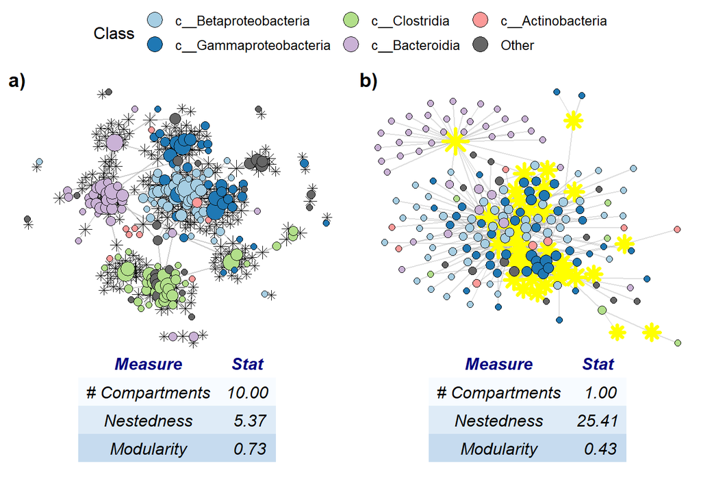

```r
### format class variable

classes_to_keep<-c("c__Betaproteobacteria","c__Gammaproteobacteria","c__Clostridia" , "c__Bacteroidia","c__Actinobacteria"  )
gg_net_AMR$Class_plot<- ifelse(gg_net_AMR$Class %in% classes_to_keep, as.character(gg_net_AMR$Class), "Other")
gg_net_AMR$Class_plot<-factor(gg_net_AMR$Class_plot, levels = c(classes_to_keep, "Other"))


### code for plasmid

gg_net_AMR$Phylum <-ifelse(is.na(gg_net_AMR$Phylum), "Plasmid", as.character(gg_net_AMR$Phylum))


###### plot



plot_AMR<-ggplot(gg_net_AMR, aes(x = x, y = y, xend = xend, yend = yend)) +
  geom_edges( color = "darkgrey", alpha = 0.4) +
  scale_size(range = c(2,6))+
  theme_blank()+
  scale_fill_manual(values = mypal3[c(1,2,3,9,5,20)])+

  geom_nodes(data = subset(gg_net_AMR,Phylum == "Plasmid"), pch = 8,  aes(size = degree), col = "yellow", stroke = 2)+

   geom_nodes(data = subset(gg_net_AMR, Phylum != "Plasmid"), aes(fill = Class_plot, size = degree ), pch = 21)+
  guides(size = "none")+
  guides(fill=guide_legend(ncol=3, override.aes = list(size = 5)))+
  labs(fill = "Class")+
   annotation_custom(tableGrob(network_metrics_AMR, rows = NULL, theme = tt3), xmin=0.3, xmax=0.7, ymin=-0.5, ymax=0)+
  ylim(c(-0.5, 1))



ggarrange(plot_noAMR, plot_AMR, ncol = 2, legend = "top", common.legend = T, labels = c("a)", "b)"))
```

## 3.4 Phylogenetic tree with barplot

```r
## tree figure
tree_class<-ggtree(tree_rooted, branch.length = "none")+
  geom_cladelabel(node=415,  col=mypal3[1], label ="", barsize=5, offset = 0.5, align=T, angle=270, offset.text=0.1, hjust='center') + #betaproteobacteri
  geom_cladelabel(node=440, col=mypal3[2],  label ="",barsize=5, offset = 0.5, align=T, angle=270, offset.text=0.1, hjust='center') + #gamma pr
  geom_cladelabel(node=464, col=mypal3[9],  label ="", barsize=5, offset = 0.5,align=T, angle=270, offset.text=0.1, hjust='center') + #Bacteroidaceae
  geom_cladelabel(node=379, col=mypal3[3],  label ="", barsize=5, offset = 0.5,align=T, angle=270, offset.text=0.1, hjust='center') + # clostridia
  geom_cladelabel(node=482, col=mypal3[5],  label ="", barsize=5, offset = 0.5, align=T, angle=270, offset.text=0.1, hjust='center')+  #actinobacteria
   theme(plot.margin = margin(0.2, 0.2, 1.6, 0.2, "cm"))

head(bacteria_alpha)
```

|  | Number | id | Identity |
| --- | --- | --- | --- |
| bin_1 | 2 | bin_1 | MAG |
| bin_10 | 3 | bin_10 | MAG |
| bin_103 | 6 | bin_103 | MAG |
| bin_104 | 10 | bin_104 | MAG |
| bin_105 | 2 | bin_105 | MAG |
| bin_106 | 1 | bin_106 | MAG |

```r
classes_to_keep<-c("c__Betaproteobacteria","c__Gammaproteobacteria","c__Clostridia" , "c__Bacteroidia","c__Actinobacteria"  )


head(taxonomy)
```

|  | Bin | Phylum | Class | Order | Family | Genus | Species | Distance |
| --- | --- | --- | --- | --- | --- | --- | --- | --- |
| 1 | bin_361 | p__Firmicutes | c__Tissierellia | o__Tissierellales | f__Tissierellaceae | g__Tissierella | s__Tissierella_creatinophila | 0.3395860 |
| 2 | bin_15 | p__Proteobacteria | c__Betaproteobacteria | o__Burkholderiales | f__Comamonadaceae | g__Acidovorax | s__Acidovorax_sp_GW101_3H11 | 0.1917310 |
| 3 | bin_180 | p__Bacteroidetes | c__CFGB2107 | o__OFGB2107 | f__FGB2107 | g__GGB6000 | s__GGB6000_SGB8623 | 0.2873090 |
| 4 | bin_177 | p__Actinobacteria | c__Actinobacteria | o__Propionibacteriales | f__Propionibacteriaceae | g__Propionibacterium | s__Propionibacterium_acidifaciens | 0.2661355 |
| 5 | bin_277 | p__Bacteroidetes | c__Bacteroidia | o__Bacteroidales | f__Prevotellaceae | g__GGB1234 | s__GGB1234_SGB1613 | 0.1031755 |
| 6 | bin_129 | p__Firmicutes | c__Clostridia | o__Clostridiales | f__Clostridiaceae | g__Alkaliphilus | s__Alkaliphilus_metalliredigens | 0.3532800 |

```r
bacteria_alpha<-merge(bacteria_alpha, taxonomy, by.x = "id", by.y = "Bin")

dim(bacteria_alpha)
```

```
## [1] 374  10
```

```r
bacteria_alpha_filt<-subset(bacteria_alpha, Class %in% classes_to_keep)


bacteria_alpha_filt$Class<-factor(bacteria_alpha_filt$Class, levels = rev(classes_to_keep))

barplot<-ggplot(bacteria_alpha_filt, aes(y = Class, x = Number, group = Class, fill = Class))+
  geom_boxplot(aes(fill = Class), outlier.shape = NA)+
  scale_fill_manual(values =rev(mypal3[c(1,2,3,9,5)]) )+
  geom_jitter(height = 0.1, pch = 21)+
 # scale_x_sqrt()+
  theme_bw(base_size = 12) +
  scale_y_discrete(position = "right")+
  scale_x_sqrt(breaks = c(0,1, 5, 10,20,30,40,50))+
  theme(legend.position = "none")+
  xlab("Number of plasmids")+
  ylab("")

fig1a<-ggarrange(tree_class, barplot, widths = c(1,3))
```

### 3.4.1 AMR boxplot

```r
head(plasmid_prev_df )
```

|  | Cluster | Prev | Abundance | Rel_Abundance | Resistance | TotalLengthKB | ContigNo |
| --- | --- | --- | --- | --- | --- | --- | --- |
| 1 | 4 | 80 | 1337 | 0.007289560 | TRUE | 78669 | 10 |
| 2 | 24 | 45 | 4897 | 0.026699307 | TRUE | 6757 | 2 |
| 3 | 144 | 39 | 1205 | 0.006569872 | TRUE | 13835 | 2 |
| 4 | 52 | 35 | 6761 | 0.036862164 | TRUE | 7357 | 3 |
| 5 | 2 | 34 | 2839 | 0.015478728 | TRUE | 6108 | 5 |
| 6 | 7 | 32 | 317 | 0.001728340 | TRUE | 73524 | 9 |

```r
plasmid_prev_df %>% group_by(Resistance) %>% summarize(mean = mean(Prev), median = median(Prev))
```

| Resistance | mean | median |
| --- | --- | --- |
| FALSE | 3.322957 | 2 |
| TRUE | 14.031250 | 7 |

```r
wilcox.test(Prev ~ Resistance, data=plasmid_prev_df)
```

```
##
##  Wilcoxon rank sum test with continuity correction
##
## data:  Prev by Resistance
## W = 1379, p-value = 3.58e-10
## alternative hypothesis: true location shift is not equal to 0
```

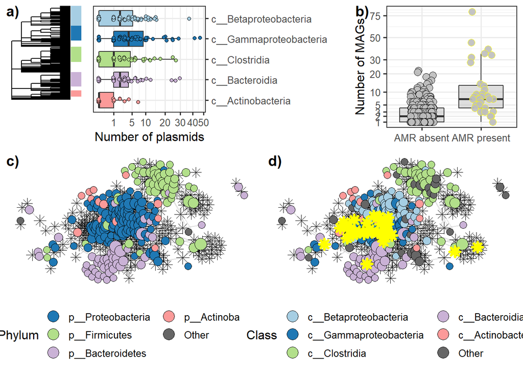

```r
fig1b<-ggplot(plasmid_prev_df, aes(x = Resistance, y = Prev, label = Cluster))+
        geom_boxplot(alpha = 0.5, outlier.shape = NA, fill = "grey")+
        geom_jitter( alpha = 0.9, width = 0.2, height = 0.01, pch = 21, fill = "grey", size = 3, aes(col = Resistance)) +
        ylab("Number of MAGs")+
        xlab("AMR gene presence")+
        theme(strip.background =element_rect(fill="white"))+
  scale_y_sqrt(breaks = c(1,2,3,5,10,20,30,50,75,100))+
 theme_bw(base_size = 12)+
  theme(legend.position = "none")+
  scale_color_manual(values = c("black", "yellow"))+
  scale_x_discrete(labels=c("AMR absent", "AMR present")) +
  theme(axis.title.x = element_blank())


fig1ab<-ggarrange(fig1a, fig1b, widths = c(2,1), labels = c("a)", "b)"))


ggarrange(fig1ab, Fig1cd, ncol = 1, heights = c(1,1.5))
```